# Conversations and Attitudes About Mental Health in Twitter Discourse

Payal Sen, Harshitha Shabad

2/23/2020

### Problem Description:

**What mental health topics do people discuss on Twitter?** **Twitter data to analyse mental health issues.**

Libraries used

```r
#install.packages("textdata")
library(textdata)
library(dplyr)
library(tidyverse)
library(tidytext)
library(stringr)
library(knitr)
library(kableExtra)
library(ggplot2)
library(RColorBrewer)
library(ggthemes)
library(wordcloud)
library(reshape2)
library(ggmap)
library(rtweet)
```

Read the dataset

In order to capture Twitter data, we had to follow the next steps:

1. We needed a Twitter application and hence created a Twitter developer account.
2. After registration, we grabbed our API keys and access tokens from Twitter: Consumer Key, Consumer Secret, Access Token and Access Token Secret.
3. Install rtweet package in RStudio environment.
4. Ran the following script with the API keys and access tokens as input parameters.
5. The hashtags considered for this analysis are as following:
- **#mentalhealth** ,
- **#depression** ,
- **#worldmentalhealthday** ,
- **#WMHD**,
- **#nostigma** ,
- **#nostigmas** ,
- **#eatingdisorders**,
- **#suicide**,
- **#ptsd**,
- **#mentalhealthawareness**,
- **#mentalillness**,
- **#stopsuicide**,
- **#IAmStigmaFree**,
- **#suicideprevention**,
- **#MH**,
- **#addiction**,
- **#bipolar**,
- **#stigma**
5. We were able to download almost 18K records on a single try.

```r
##app_name <- "pearlhack2020_twitter_app"
##consumer_key <- "VTXJmEplfjEWN2PLeMw2IeEVO"
##consumer_secret <- "DKRJgWmeXWUFnRPxKnLYmhtfTem6kWUVW9WYH2IbzTqFQdazWE"

## create token
##token <- create_token(app_name, consumer_key, consumer_secret)

##terms <- c("#mentalhealth" ,"#depression" ,"#worldmentalhealthday" ,"#WMHD", "#nostigma" ,
##           "#nostigmas" , "#eatingdisorders", "#suicide", "#ptsd", "#mentalhealthawareness",
##           "#mentalillness","#stopsuicide", "#IAmStigmaFree", "#suicideprevention", "#MH", "#addiction",
##           "#bipolar", "#stigma")

##terms_search <- paste(terms, collapse = " OR ")

##mh_data <- search_tweets(terms_search, n=20000, lang="en", retryonratelimit = TRUE)


##write.csv(mh_tweets,"c:/Users/psen2/Desktop/PearlHacks/Final_Project/tweets.csv",
##         append=T, row.names=F, col.names=T,  sep=",")
tweets_df = read_csv('tweets.csv')
names(tweets_df)
```

```
##  [1] "user_id"                 "status_id"
##  [3] "created_at"              "screen_name"
##  [5] "text"                    "source"
##  [7] "display_text_width"      "reply_to_status_id"
##  [9] "reply_to_user_id"        "reply_to_screen_name"
## [11] "is_quote"                "is_retweet"
## [13] "favorite_count"          "retweet_count"
## [15] "quote_count"             "reply_count"
## [17] "ext_media_type"          "lang"
## [19] "quoted_status_id"        "quoted_text"
## [21] "quoted_created_at"       "quoted_source"
## [23] "quoted_favorite_count"   "quoted_retweet_count"
## [25] "quoted_user_id"          "quoted_screen_name"
## [27] "quoted_name"             "quoted_followers_count"
## [29] "quoted_friends_count"    "quoted_statuses_count"
```

[output cut: 22 more lines]

### Data Cleaning

- Removed unneccessary columns
- Removed html tags and mental health tags

```r
tweets_df = tweets_df %>%
  mutate(text = str_replace_all(text, "(<br />)+", " "),
         text = str_replace_all(text, "@", ""),
         text = str_replace_all(text, "mentalhealth", ""),
         text = str_replace_all(text, "t.co", ""),
         text = str_replace_all(text, "http", "")) %>%
  select(user_id, created_at,text,country,country_code)

names(tweets_df)
```

```
## [1] "user_id"      "created_at"   "text"         "country"
## [5] "country_code"
```

### Tokenization

- Turning the text into tokens

```r
tokens <- tweets_df %>%
  unnest_tokens(output = word, input = text)

kable(head(tokens)) %>%
  kable_styling(bootstrap_options = "striped", full_width = F, position = "left",
                fixed_thead = T)
```

| user_id | created_at | country | country_code | word |
| --- | --- | --- | --- | --- |
| 7.865932e+17 | 2020-02-23 03:10:21 | NA | NA | katiecouric |
| 7.865932e+17 | 2020-02-23 03:10:21 | NA | NA | we’re |
| 7.865932e+17 | 2020-02-23 03:10:21 | NA | NA | hoping |
| 7.865932e+17 | 2020-02-23 03:10:21 | NA | NA | you |
| 7.865932e+17 | 2020-02-23 03:10:21 | NA | NA | can |
| 7.865932e+17 | 2020-02-23 03:10:21 | NA | NA | do |

### Show common words

- We can see that ‘s’,‘to’,‘u’,‘the’,‘and’, ‘a’ are the 6 most common words

```r
head(tokens %>%
  count(word,sort = TRUE))
```

```
## # A tibble: 6 x 2
##   word      n
##   <chr> <int>
## 1 s     18419
## 2 to    15324
## 3 u     12774
## 4 the   12058
## 5 and   11338
## 6 a      9935
```

```r
common_words <- tokens %>%
  count(word,sort = TRUE) %>%
  slice(1:10)%>%
  select(word) %>% unique()

tokens <- tokens %>%
  filter(!word %in% common_words$word)

kable(head(tokens)) %>%
  kable_styling(bootstrap_options = "striped", full_width = F, position = "left",
                fixed_thead = T)
```

| user_id | created_at | country | country_code | word |
| --- | --- | --- | --- | --- |
| 7.865932e+17 | 2020-02-23 03:10:21 | NA | NA | katiecouric |
| 7.865932e+17 | 2020-02-23 03:10:21 | NA | NA | we’re |
| 7.865932e+17 | 2020-02-23 03:10:21 | NA | NA | hoping |
| 7.865932e+17 | 2020-02-23 03:10:21 | NA | NA | can |
| 7.865932e+17 | 2020-02-23 03:10:21 | NA | NA | do |
| 7.865932e+17 | 2020-02-23 03:10:21 | NA | NA | lungcancer |

### Remove stop words

- Get the stopwords from the get_stopwords() function
- Remove the stop words from the cleaned_tokens

```r
sw = get_stopwords()
sw
```

```
## # A tibble: 175 x 2
##    word      lexicon
##    <chr>     <chr>
##  1 i         snowball
##  2 me        snowball
##  3 my        snowball
##  4 myself    snowball
##  5 we        snowball
##  6 our       snowball
##  7 ours      snowball
##  8 ourselves snowball
##  9 you       snowball
## 10 your      snowball
## # ... with 165 more rows
```

```r
cleaned_tokens <- tokens %>%
  filter(!word %in% sw$word)

kable(head(cleaned_tokens)) %>%
  kable_styling(bootstrap_options = "striped", full_width = F, position = "left",
                fixed_thead = T)
```

| user_id | created_at | country | country_code | word |
| --- | --- | --- | --- | --- |
| 7.865932e+17 | 2020-02-23 03:10:21 | NA | NA | katiecouric |
| 7.865932e+17 | 2020-02-23 03:10:21 | NA | NA | hoping |
| 7.865932e+17 | 2020-02-23 03:10:21 | NA | NA | can |
| 7.865932e+17 | 2020-02-23 03:10:21 | NA | NA | lungcancer |
| 7.865932e+17 | 2020-02-23 03:10:21 | NA | NA | screening |
| 7.865932e+17 | 2020-02-23 03:10:21 | NA | NA | coloncancer |

### Remove numbers

- Get the numbers from cleaned_tokens and then remove them.

```r
nums <- cleaned_tokens %>%
  filter(str_detect(word, "^[0-9]")) %>%
  select(word) %>% unique()

nums
```

```
## # A tibble: 2,472 x 1
##    word
##    <chr>
##  1 1cancerkiller
##  2 22aday
##  3 22kill
##  4 22for22
##  5 22strong
##  6 0001f31e
##  7 0001f9a9
##  8 1.800.273.8255
##  9 0001f64f
## 10 0001f441
## # ... with 2,462 more rows
```

```r
cleaned_tokens <- cleaned_tokens %>%
  filter(!word %in% nums$word)

kable(head(cleaned_tokens)) %>%
  kable_styling(bootstrap_options = "striped", full_width = F, position = "left",
                fixed_thead = T)
```

| user_id | created_at | country | country_code | word |
| --- | --- | --- | --- | --- |
| 7.865932e+17 | 2020-02-23 03:10:21 | NA | NA | katiecouric |
| 7.865932e+17 | 2020-02-23 03:10:21 | NA | NA | hoping |
| 7.865932e+17 | 2020-02-23 03:10:21 | NA | NA | can |
| 7.865932e+17 | 2020-02-23 03:10:21 | NA | NA | lungcancer |
| 7.865932e+17 | 2020-02-23 03:10:21 | NA | NA | screening |
| 7.865932e+17 | 2020-02-23 03:10:21 | NA | NA | coloncancer |

- Almost 30K words are present in cleaned_tokens

```r
length(unique(cleaned_tokens$word))
```

```
## [1] 30443
```

### Plot 5: Plotting the Word Frequency

- Many of these words appear rarely and so we need to remove these rare words
- Plotting it in a bar graph

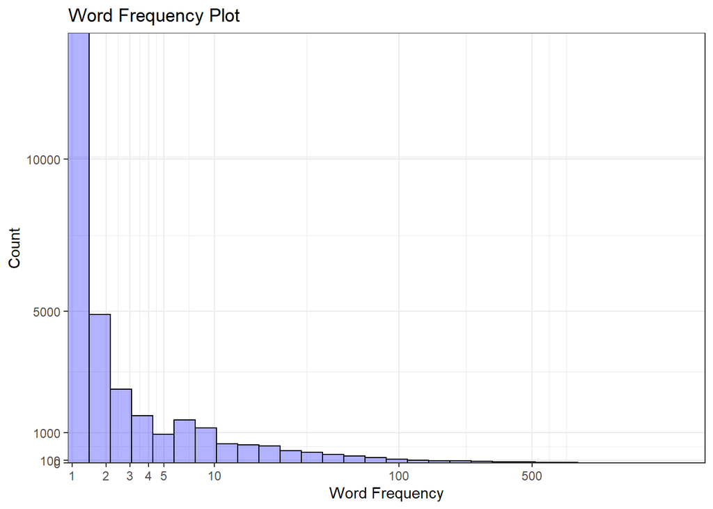

```r
cleaned_tokens %>%
  count(word, sort = T) %>%
  rename(word_freq = n) %>%
  ggplot(aes(x=word_freq)) +
  geom_histogram(aes(y=..count..), color="black", fill="blue", alpha=0.3) +
  scale_x_continuous(breaks=c(0:5,10,100,500,10e3), trans="log1p",
                     expand=c(0,0)) +
  scale_y_continuous(breaks=c(0,100,1000,5e3,10e3,5e4,10e4,4e4),
                     expand=c(0,0)) +
  labs(title="Word Frequency Plot",
       x = "Word Frequency",
       y = "Count")+
  theme_bw()
```

### Remove rare words

- It makes sense to remove rare words to improve the performance of text analytics
- Removing words that have less than 10 appearances in this collection

```r
rare <- cleaned_tokens %>%
  count(word) %>%
  filter(n<10) %>%
  select(word) %>%
  unique()
rare
```

```
## # A tibble: 26,290 x 1
##    word
##    <chr>
##  1 ___
##  2 _______________
##  3 ___________________
##  4 _________________________
##  5 _addz20
##  6 _authenticme_
##  7 _bigzeeks
##  8 _bluewolverine
##  9 _diabetesaction
## 10 _digitalindia
## # ... with 26,280 more rows
```

```r
cleaned_tokens <- cleaned_tokens %>%
  filter(!word %in% rare$word)

kable(head(cleaned_tokens)) %>%
  kable_styling(bootstrap_options = "striped", full_width = F, position = "left",
                fixed_thead = T)
```

| user_id | created_at | country | country_code | word |
| --- | --- | --- | --- | --- |
| 7.865932e+17 | 2020-02-23 03:10:21 | NA | NA | hoping |
| 7.865932e+17 | 2020-02-23 03:10:21 | NA | NA | can |
| 7.865932e+17 | 2020-02-23 03:10:21 | NA | NA | lungcancer |
| 7.865932e+17 | 2020-02-23 03:10:21 | NA | NA | screening |
| 7.865932e+17 | 2020-02-23 03:10:21 | NA | NA | screening |
| 7.865932e+17 | 2020-02-23 03:10:21 | NA | NA | former |

```r
length(unique(cleaned_tokens$word))
```

```
## [1] 4153
```

### Plot 6: Wordcloud of common words

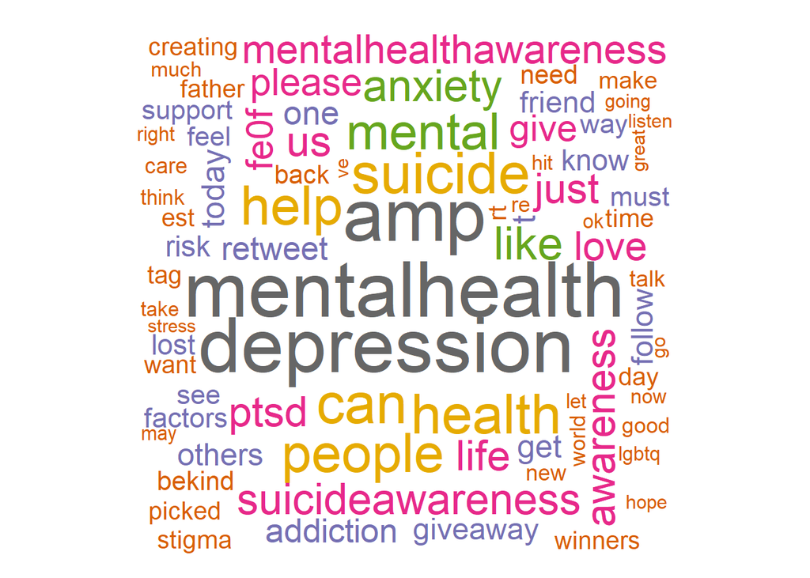

```r
# define a nice color palette
pal <- brewer.pal(8,"Dark2")

cleaned_tokens %>%
  count(word) %>%
  with(wordcloud(word, n, random.order = FALSE, max.words = 100, colors=pal))
```

### Perform sentiment analysis

- Performed based on a lexicon of sentiment keywords
- The nrc lexicon categorizes words in a binary fashion (“yes”/“no”) into categories of positive, negative, anger, anticipation, disgust, fear, joy, sadness, surprise, and trust
- The bing lexicon categorizes words in a binary fashion into positive and negative categories
- The AFINN lexicon assigns words with a score that runs between -5 and 5, with negative scores indicating negative sentiment and positive scores indicating positive sentiment
- All three of these lexicons are based on unigrams, i.e., single words

```r
sent_reviews = cleaned_tokens %>%
  left_join(get_sentiments("nrc")) %>%
  rename(nrc = sentiment) %>%
  left_join(get_sentiments("bing")) %>%
  rename(bing = sentiment) %>%
  left_join(get_sentiments("afinn")) %>%
  rename(afinn = value)

kable(head(sent_reviews %>%
  filter(nrc != "NA" | bing != "NA" | afinn != "NA") %>%
  select(-c(country, country_code, user_id, created_at)))) %>%
  kable_styling(bootstrap_options = "striped", full_width = F, position = "left",
                fixed_thead = T)
```

| word | nrc | bing | afinn |
| --- | --- | --- | --- |
| hoping | NA | NA | 2 |
| important | positive | positive | 2 |
| important | trust | positive | 2 |
| learn | positive | NA | NA |
| right | NA | positive | NA |
| cancer | anger | negative | -1 |

### Most common positive and negative words

- Getting the common positive and negative words using bing lexicon

```r
bing_word_counts <- sent_reviews %>%
  filter(!is.na(bing)) %>%
  count(word, bing, sort = TRUE)

kable(head(bing_word_counts)) %>%
  kable_styling(bootstrap_options = "striped", full_width = F, position = "left",
                fixed_thead = T)
```

| word | bing | n |
| --- | --- | --- |
| suicide | negative | 9388 |
| anxiety | negative | 8410 |
| depression | negative | 6494 |
| stigma | negative | 3740 |
| good | positive | 2955 |
| love | positive | 2902 |

### Plot 7: Comparison wordcloud of positive and negative sentiments

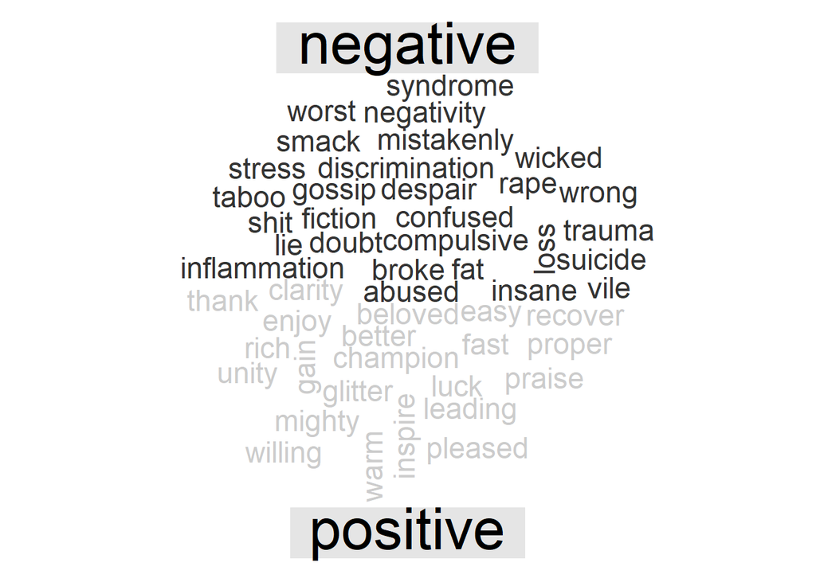

```r
bing_word_counts %>%
  inner_join(get_sentiments("bing")) %>%
  count(word, sentiment, sort = TRUE) %>%
  acast(word ~ sentiment, value.var = "n", fill = 0) %>%
  comparison.cloud(scale =c(1.5,0.25),
                   max.words = 50,
                   colors = c("gray20", "gray80")
                   )
```

### Plot8: Sentiment by Words

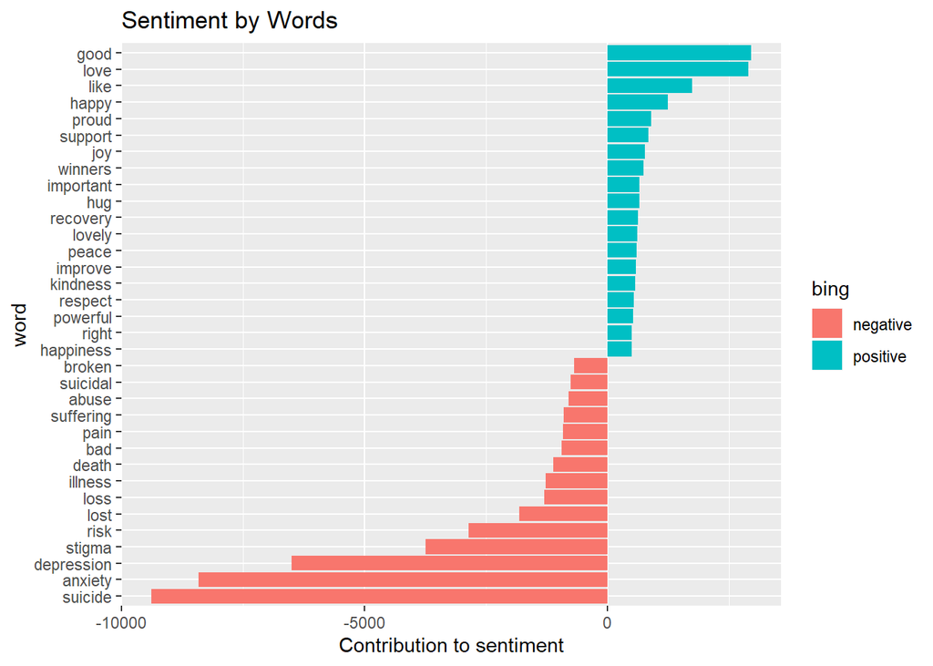

```r
bing_word_counts %>%
  filter(n > 500) %>%
  mutate(n = ifelse(bing == "negative", -n, n)) %>%
  mutate(word = reorder(word, n)) %>%
  ggplot(aes(word, n, fill = bing)) +
  geom_col() +
  coord_flip() +
  labs(title = "Sentiment by Words",
    y = "Contribution to sentiment")
```